# Joint impact of dams and water quality on food webs

The goal of this notebook is to quantify jointly the impact of large dams and water quality on food web structure. It follows the structure of D13, which did it for dams only, and adds the water quality index of D14. To do so, we

- keep the food webs of D13 at the visits with a predicted water quality
- model the impact of dams and water quality on the descriptors of food web structure, together in the same model
- check whether the dam effects of D13 hold once water quality is accounted for
- investigate how the impacts of the two stressors are mediated by species.

Following D14, we keep the two stressors additive: their interaction on species presence was weak and inconsistent across species.

## Setup

```r
library(renv)
renv::load()
library(targets)
library(here)
tar_config_set(
  store = here::here("_targets")
)
library(ggplot2)
library(dplyr)
devtools::load_all()
nice_theme()
```

## Food webs and water quality

### Data

We use the observed food webs of D13 and their descriptors, at the visits whose site is a NAIADES station, with the water quality index (PC1 of D14) predicted in the visit year. Water quality is centred and scaled over these visits, so its effects are per standard deviation; higher values mean better water quality (less nutrients, more oxygen). The two axes of the PCA of the descriptors of D13 are kept: PC1, the simplicity axis, and PC2, the richness to top-heaviness gradient. To avoid confusion with the water quality index, we call these axes “Structure PC1” and “Structure PC2”.

```r
metric_label <- c(
  fish_richness = "Fish richness",
  mean_trophic_level = "Mean trophic level",
  fish_diet_overlap = "Fish diet overlap",
  trophic_redundancy = "Trophic redundancy",
  log_biomass = "Total biomass (log)",
  biomass_trophic_level = "Mean trophic level (biomass)",
  biomass_pyramid = "Biomass-trophic level correlation",
  PC1 = "Structure PC1 (simplicity)",
  PC2 = "Structure PC2 (richness to top-heaviness)"
)
web <- tar_read(quality_foodweb)
tibble(
  webs = c("D13", "with water quality"),
  visits = c(nrow(tar_read(dam_foodweb)), nrow(web)),
  sites = c(n_distinct(tar_read(dam_foodweb)$site), n_distinct(web$site))
) |>
  knitr::kable(format.args = list(big.mark = ","))
```

| webs | visits | sites |
| --- | --- | --- |
| D13 | 5,901 | 1,679 |
| with water quality | 5,525 | 1,479 |

### Dams and water quality

If dams and water quality were strongly correlated, their effects could not be separated. We plot the water quality of the visits against their dam accumulation.

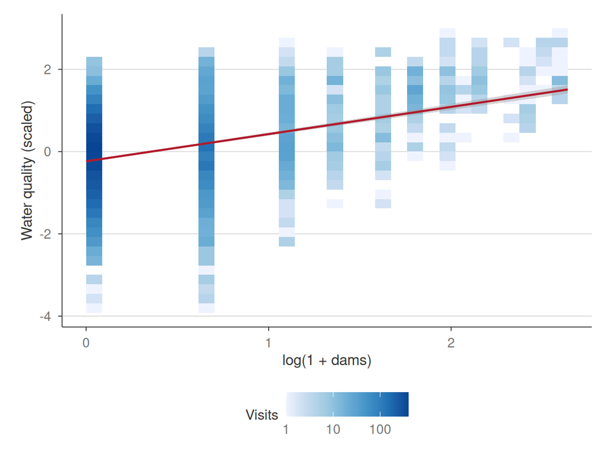

```r
ggplot(web, aes(accumulation, quality)) +
  geom_bin_2d(bins = 30) +
  geom_smooth(method = "lm", color = "#B2182B", linewidth = 0.7) +
  scale_fill_distiller(palette = "Blues", direction = 1, transform = "log10") +
  labs(x = "log(1 + dams)", y = "Water quality (scaled)", fill = "Visits")
```

```r
tibble(
  `Spearman correlation` = cor(web$accumulation, web$quality, method = "spearman")
) |>
  knitr::kable(digits = 2)
```

| Spearman correlation |
| --- |
| 0.29 |

Next, the Spearman correlation of water quality with each descriptor, before any control.

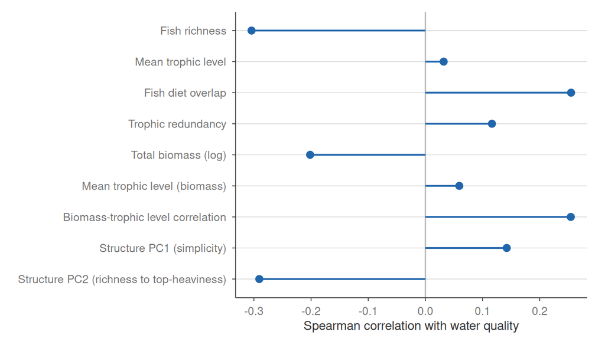

```r
tibble(
  metric = names(metric_label),
  rho = purrr::map_dbl(metric, \(m) cor(web[[m]], web$quality, method = "spearman", use = "complete.obs"))
) |>
  mutate(metric = factor(metric_label[metric], rev(metric_label))) |>
  ggplot(aes(rho, metric)) +
  geom_vline(xintercept = 0, color = "grey70") +
  geom_segment(aes(x = 0, xend = rho, yend = metric), color = "#2166AC", linewidth = 0.7) +
  geom_point(color = "#2166AC", size = 2.5) +
  labs(x = "Spearman correlation with water quality", y = NULL)
```

## Model dam and water quality impacts on food web structure

Each descriptor is modelled as in D13 (position controls, sampling effort, site and year effects, spatial field; Poisson for fish richness, Gaussian otherwise), with dam accumulation and water quality in the same model.

```r
setting <- tar_read(quality_structure_setting)
metric_sd <- web |>
  summarise(across(all_of(names(metric_label)), \(x) sd(x, na.rm = TRUE))) |>
  tidyr::pivot_longer(everything(), names_to = "metric", values_to = "sd")
structure_effect <- purrr::map_dfr(seq_len(nrow(setting)), \(i) {
  tar_read(quality_structure_model)[[i]]$summary.fixed |>
    as_tibble(rownames = "term") |>
    filter(term %in% c("accumulation", "quality")) |>
    transmute(metric = setting$metric[i], term, mean, lower = `0.045quant`, upper = `0.955quant`)
}) |>
  left_join(metric_sd, by = "metric") |>
  # Gaussian metrics on the sd scale, to compare them; richness stays on the
  # log scale.
  mutate(across(c(mean, lower, upper), \(x) if_else(metric == "fish_richness", x, x / sd)))
stressor_label <- c(accumulation = "Dam accumulation", quality = "Water quality")
```

Effects of the two stressors in the joint model: dam effect per unit of $\log(1 + \text{dams})$, water quality effect per standard deviation; Gaussian descriptors in standard deviations, fish richness on the log scale.

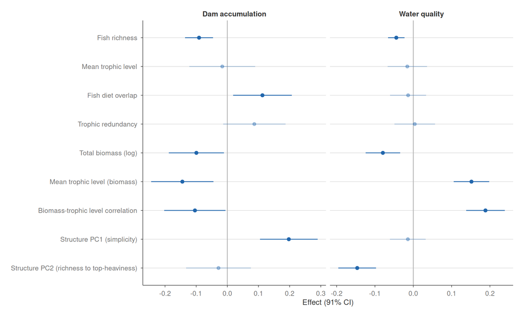

```r
structure_effect |>
  mutate(
    metric = factor(metric_label[metric], rev(metric_label)),
    term = factor(stressor_label[term], stressor_label),
    credible = sign(lower) == sign(upper)
  ) |>
  ggplot(aes(mean, metric, alpha = credible)) +
  geom_vline(xintercept = 0, color = "grey70") +
  geom_pointrange(aes(xmin = lower, xmax = upper), size = 0.3, color = "#2166AC") +
  scale_alpha_manual(values = c(`TRUE` = 1, `FALSE` = 0.35), guide = "none") +
  facet_wrap(~term, scales = "free_x") +
  labs(x = "Effect (91% CI)", y = NULL)
```

## How species mediate the impacts on food web structure

As in D13, we ask which species mediate the effects on food web structure. Each stressor is followed on the structure axis it acts on: Structure PC1 for the dams, Structure PC2 for water quality. The contribution of species $s$ to the effect of a stressor on its axis is
$$\beta_s \, \overline{p_s (1 - p_s)} \, (-r_s),$$
with $\beta_s$ the effect of the stressor on the presence of $s$ (logit scale), from the presence model of D14 with dams and water quality (additive, with spatial field), $p_s$ its fitted presence probability, and $r_s$ the change of the axis when $s$ is removed from the webs (computed on the D13 webs). The expected effect is the sum over the species. The uncertainty of $\beta_s$ and $r_s$ is propagated by drawing both, and the null model shuffles the effects $\beta_s$ among the species.

```r
mediation_setting <- tar_read(mediation_setting) |>
  mutate(term = c(accumulation = "accumulation", PC1 = "quality")[stressor]) # Term in the structure models.
decomposition <- setNames(tar_read(stressor_decomposition), mediation_setting$term)
permutation <- setNames(tar_read(stressor_permutation), mediation_setting$term)
axis_label <- setNames(paste("Structure", mediation_setting$axis), mediation_setting$term)
removal_effect <- tar_read(quality_removal_effect) |>
  select(species, metric, importance = mean, importance_lower = lower, importance_upper = upper)
species_mediation <- purrr::imap_dfr(decomposition, \(d, term) {
  d$species |>
    left_join(removal_effect, by = c("species", "metric")) |>
    mutate(stressor = term)
})
```

Effect of each stressor on its structure axis estimated by the joint model, predicted from the change of species presence, and predicted from the same changes shuffled among species.

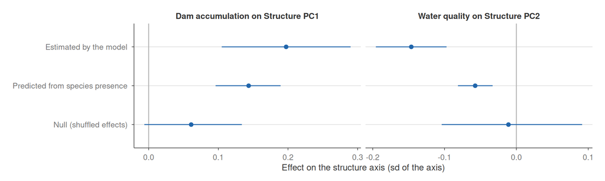

```r
estimate_level <- c(
  "Estimated by the model", "Predicted from species presence", "Null (shuffled effects)"
)
stressor_axis_label <- setNames(
  paste(stressor_label[mediation_setting$term], "on", axis_label),
  mediation_setting$term
)
bind_rows(
  structure_effect |>
    inner_join(mediation_setting, by = c(metric = "axis", term = "term")) |>
    transmute(stressor = term, estimate = estimate_level[1], mean, lower, upper),
  purrr::map_dfr(mediation_setting$term, \(term) bind_rows(
    decomposition[[term]]$draw |> mutate(estimate = estimate_level[2]),
    permutation[[term]] |> mutate(estimate = estimate_level[3])
  ) |>
    summarise(
      mean = mean(change), lower = quantile(change, 0.045), upper = quantile(change, 0.955),
      .by = estimate
    ) |>
    mutate(stressor = term))
) |>
  mutate(
    estimate = factor(estimate, rev(estimate_level)),
    stressor = factor(stressor_axis_label[stressor], stressor_axis_label)
  ) |>
  ggplot(aes(mean, estimate)) +
  geom_vline(xintercept = 0, color = "grey70") +
  geom_pointrange(aes(xmin = lower, xmax = upper), size = 0.3, color = "#2166AC") +
  facet_wrap(~stressor, scales = "free_x") +
  labs(x = "Effect on the structure axis (sd of the axis)", y = NULL)
```

**Results:** for dams, D13 holds: the change of species presence predicts a large part of the estimated effect on Structure PC1, and much more than the null model (only 3% of the shuffles reach it), so dams hit the species that matter for the structure. For water quality, the change of species presence predicts about 40% of the estimated effect on Structure PC2, with the right sign. But the null model reaches it in a third of the shuffles: water quality does not specifically hit the species that matter for Structure PC2.

Decomposition of the predicted effect at the species level, for the 15 species with the strongest mediated effect of each stressor.

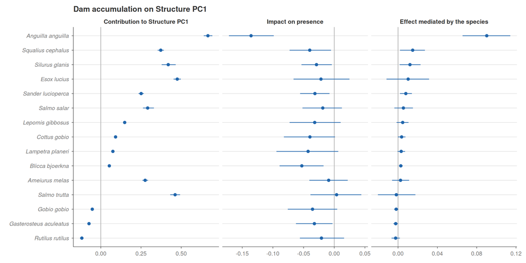

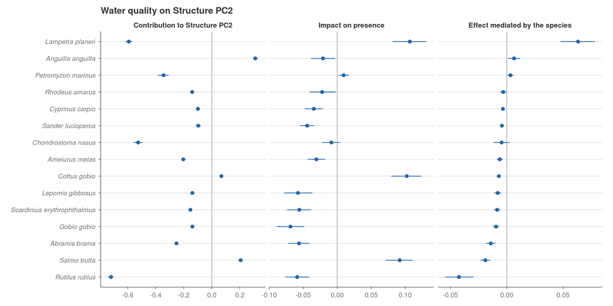

```r
plot_mediation <- function(mediation, term) {
  species_step <- c(
    importance = paste("Contribution to", axis_label[term]),
    presence = "Impact on presence",
    contribution = "Effect mediated by the species"
  )
  bind_rows(
    mediation |> transmute(species, step = "importance", mean = importance, lower = importance_lower, upper = importance_upper),
    mediation |> transmute(species, step = "presence", mean = presence, lower = presence_lower, upper = presence_upper),
    mediation |> transmute(species, step = "contribution", mean = contribution, lower, upper)
  ) |>
    semi_join(slice_max(mediation, abs(contribution), n = 15), by = "species") |>
    mutate(
      step = factor(species_step[step], species_step),
      species = factor(species, arrange(mediation, contribution)$species)
    ) |>
    ggplot(aes(mean, species)) +
    geom_vline(xintercept = 0, color = "grey70") +
    geom_pointrange(aes(xmin = lower, xmax = upper), size = 0.3, color = "#2166AC") +
    facet_wrap(~step, scales = "free_x") +
    labs(x = NULL, y = NULL, title = stressor_axis_label[term]) +
    theme(axis.text.y = element_text(face = "italic"))
}
species_mediation |>
  split(~stressor) |>
  purrr::iwalk(\(mediation, term) print(plot_mediation(mediation, term)))
```

**Results:** the eel still mediates most of the dam effect on Structure PC1. For water quality, clean water lowers Structure PC2 (fewer species, more top-heavy webs) through two groups of species: the loss of tolerant lowland cyprinids (roach, bream, gudgeon, rudd) and of the pumpkinseed, and the gain of the brown trout and the sculpin. The brook lamprey works the other way: it is more frequent in clean water and its presence raises Structure PC2, which offsets part of the effect.

To separate the number of species from their identity, we split each predicted effect as in D13. With $a_s = \beta_s \overline{p_s (1 - p_s)}$ the change of presence of species $s$, and $\bar{a}$ its mean over the species,
$$\Delta = \bar{a} \sum_s (-r_s) + \sum_s (a_s - \bar{a}) (-r_s).$$
The first term is the effect if the stressor changed the presence of all species equally (the number of species), the second the effect of the stressor changing some species more than others (which species). The bars below the top one split the second part by species.

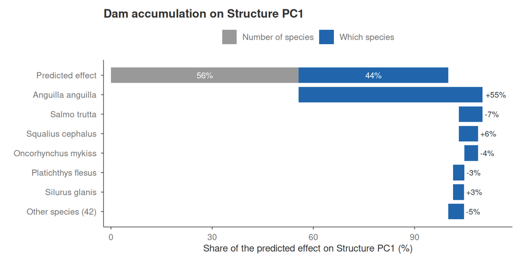

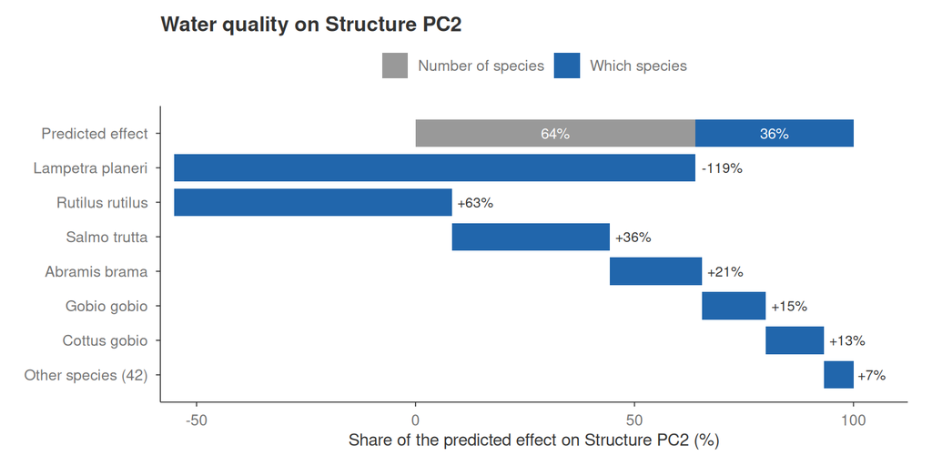

```r
plot_split <- function(mediation, term) {
  mean_presence <- mean(mediation$presence)
  species_identity <- mediation |>
    transmute(item = species, value = (presence - mean_presence) * -importance) |>
    arrange(desc(abs(value)))
  n_shown <- 6
  species_identity <- bind_rows(
    head(species_identity, n_shown),
    tibble(
      item = paste0("Other species (", nrow(species_identity) - n_shown, ")"),
      value = sum(species_identity$value[-seq_len(n_shown)])
    )
  )
  number_part <- mean_presence * sum(-mediation$importance)
  total <- number_part + sum(species_identity$value)
  # Parts in percentage of the predicted effect.
  number_part <- 100 * number_part / total
  species_identity <- mutate(species_identity, value = 100 * value / total)
  split_part <- bind_rows(
    tibble(
      item = "Predicted effect",
      part = c("Number of species", "Which species"),
      start = c(0, number_part), end = c(number_part, 100)
    ),
    species_identity |>
      mutate(
        end = number_part + cumsum(value), start = lag(end, default = number_part),
        part = "Which species"
      )
  ) |>
    mutate(position = match(item, unique(item)), value = end - start)
  ggplot(split_part) +
    geom_rect(
      aes(xmin = pmin(start, end), xmax = pmax(start, end),
          ymin = position - 0.4, ymax = position + 0.4, fill = part)
    ) +
    geom_text(
      aes(x = (start + end) / 2, y = position, label = sprintf("%.0f%%", value)),
      data = filter(split_part, position == 1), color = "white", size = 3.2
    ) +
    geom_text(
      aes(x = pmax(start, end), y = position, label = sprintf("%+.0f%%", value)),
      data = filter(split_part, position > 1), hjust = -0.15, color = "grey20", size = 3
    ) +
    scale_y_reverse(breaks = unique(split_part$position), labels = unique(split_part$item)) +
    scale_x_continuous(expand = expansion(mult = c(0.02, 0.08))) +
    scale_fill_manual(values = c(`Number of species` = "grey60", `Which species` = "#2166AC")) +
    labs(
      x = paste("Share of the predicted effect on", axis_label[term], "(%)"), y = NULL, fill = NULL,
      title = stressor_axis_label[term]
    ) +
    theme(legend.position = "top", panel.grid.major.y = element_blank())
}
species_mediation |>
  split(~stressor) |>
  purrr::iwalk(\(mediation, term) print(plot_split(mediation, term)))
```

**Results:** as in D13, about half of the predicted dam effect comes from the number of species lost, and the rest mostly from the eel being hit harder than the other species. For water quality, most of the predicted effect comes from the number of species (clean water holds fewer species). The identity part is the balance of large opposite parts, the brook lamprey on one side, the roach, the trout and the other species on the other, so its shares are large and mostly cancel.

## Conclusion

- Dams and water quality are only moderately correlated at the fish visits.
- The two stressors act on different dimensions of the webs. Dams simplify them (Structure PC1), mostly through the loss of the eel. Water quality shifts them along Structure PC2: where the water is clean, webs hold fewer species and more of their biomass high in the web.
- The water quality effect on Structure PC2 goes mostly through the number of species, with clean water replacing tolerant lowland cyprinids by the trout and the sculpin; the brook lamprey partly offsets it.

*To discuss:* the change of species presence predicts only part of the water quality effect on Structure PC2; the rest may come from changes in abundance and size structure, which presence does not capture. The removal effects $r_s$ come from all the D13 webs, not only those with water quality, and the uncertainty of the predicted water quality is not propagated.